# Principal components analysis

Gerko Vink

Statistical Programming in R

## Recap

So far, we mostly investigated (bivariate) relations between observed data points.

This lecture we are considering multivariate relations and patterns.

We focus on Principal Components Analysis (PCA)

# Principal Components Analysis

## What is it

All the techniques we discussed so far are based on hypotheses testing (t-test, F-test, chi-square test). Also, the techniques require observed variables (DV and IVs).

However, sometimes we have a large number of observed variables, and we think that some of them measure an underlying dimension (e.g., intelligence, attitude towards drugs, extraversion, etc.).

The underlying dimensions are not observed: these are latent variables (also called factors or constructs).

## Why factor analysis (and PCA)

Many theoretical constructs cannot be observed directly: We say such constructs are latent.

We try to infer their existence from the relations (correlations) between the observed variables.

$$\rho_{X,Y} = \frac{\text{cov}(X,Y)}{\sigma_X\sigma_Y} = \frac{E[(X - \mu_{X})(Y-\mu_{Y})]}{\sigma_X\sigma_Y}$$

Because we try to understand the relations between the observed variables using a smaller number of latent variables, factor analysis is a form of data reduction

## PCA = data transformation

Originally, PCA is a form of data transformation (not data reduction).

The first principal component is a linear combination of the observed variables, which explains most of the total observed variance.

Then second principal component is a linear combination of the observed variables, which explains most of the variance that was not accounted for by the first component.

This is continued until we have as many components as observed variables: no data reduction but data transformation

## Visual example

Suppose we have two observed variables. Hence, there are two principal components, which describe all observed variance.

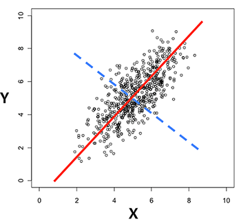

The solid red line represents the first principal component: it is a linear combination of the two original variables for which the explained variance is maximal.

The second principal component (dotted blue line) must be perpendicular to the first, to explain variance unaccounted for by the first principal component

## Eigenvalues

Total variance in items:

- Per item the variance is 1
- The total variance = number of items = $k$

Eigenvalue ($\lambda$) of a component is the variance explained in all items by the component.

$$\lambda = \sum^{k}_{g=1} = a^2_{gj}$$

- $k$ is the number of items
- $a^2_{gj}$ = factorloading of item $g$ on factor (component) $j$

A component with an eigenvalue $\lambda > 1$ explains more variance than a single item (hence datareduction).

## Communalities and Loadings

A communality is the proportion of jointly explained variance by all factors/components in one item (variable).

- Uniqueness is the proportion of not-explained variance in one item (1 – communality)

Component loadings are the regression coefficients when regressing the observations on the components.

- Loadings are equal to the correlations between the observations and the components.

## Possum data

The possum data frame consists of nine morphometric measurements on each of 104 mountain brushtail possums, trapped at seven sites from Southern Victoria to central Queensland.

```r
require(DAAG)
head(possum)
```

```
##     case site Pop sex age hdlngth skullw totlngth taill footlgth earconch
## C3     1    1 Vic   m   8    94.1   60.4     89.0  36.0     74.5     54.5
## C5     2    1 Vic   f   6    92.5   57.6     91.5  36.5     72.5     51.2
## C10    3    1 Vic   f   6    94.0   60.0     95.5  39.0     75.4     51.9
## C15    4    1 Vic   f   6    93.2   57.1     92.0  38.0     76.1     52.2
## C23    5    1 Vic   f   2    91.5   56.3     85.5  36.0     71.0     53.2
## C24    6    1 Vic   f   1    93.1   54.8     90.5  35.5     73.2     53.6
##      eye chest belly
## C3  15.2  28.0    36
## C5  16.0  28.5    33
## C10 15.5  30.0    34
## C15 15.2  28.0    34
## C23 15.1  28.5    33
## C24 14.2  30.0    32
```

## Plotting data features

```r
require(lattice)
colr <- c("red", "blue")
pchr <- c(3,4,0,8,2,10,1)
ss <- expand.grid(site=1:7, sex=1:2)           # Site varies fastest
parset <- with(ss, simpleTheme(pch=pchr[site], col=colr[sex]))
sitenames <- c("Cambarville","Bellbird","Whian Whian", "Byrangery",
               "Conondale ","Allyn River", "Bulburin")
## Add column sexsite to possum; will be used again below
possum$sexsite <- paste(possum$sex, possum$site, sep="-")
splom(possum[, c(9:11)], groups = possum$sexsite,
      col = colr[ss$sex], par.settings=parset,
      varnames=c("tail\nlength","foot\nlength","ear conch\nlength"),
      key = list(text=list(sitenames), points=list(pch=pchr), columns=3))
```

## Plotting data features

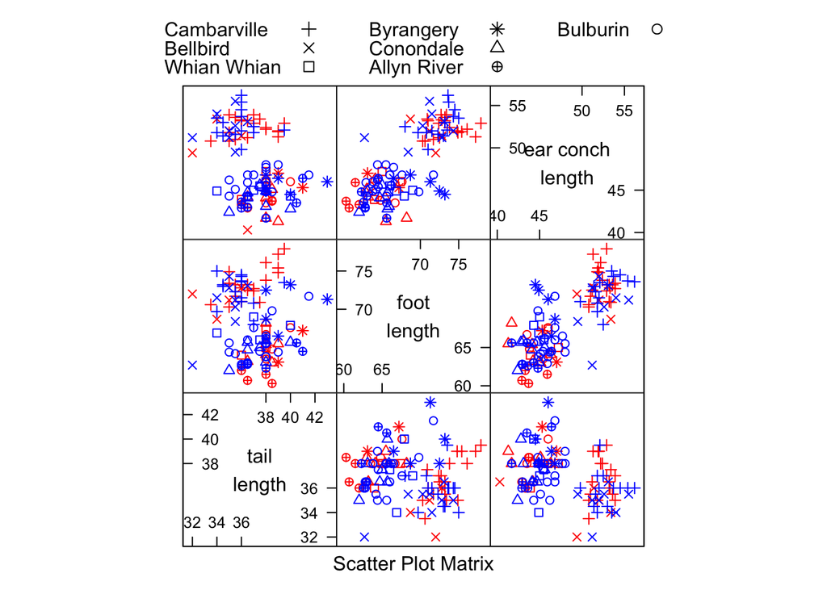

## And for graph junks

```r
cloud(earconch~taill+footlgth, data=possum, pch=pchr, groups=site,
      par.settings=simpleTheme(pch=c(3,4,0,8,2,10,1)),
      auto.key = list(space="top", corner=c(0,1), columns=3, between=1,
                 text=sitenames, between.columns=2))
```

## And for graph junks

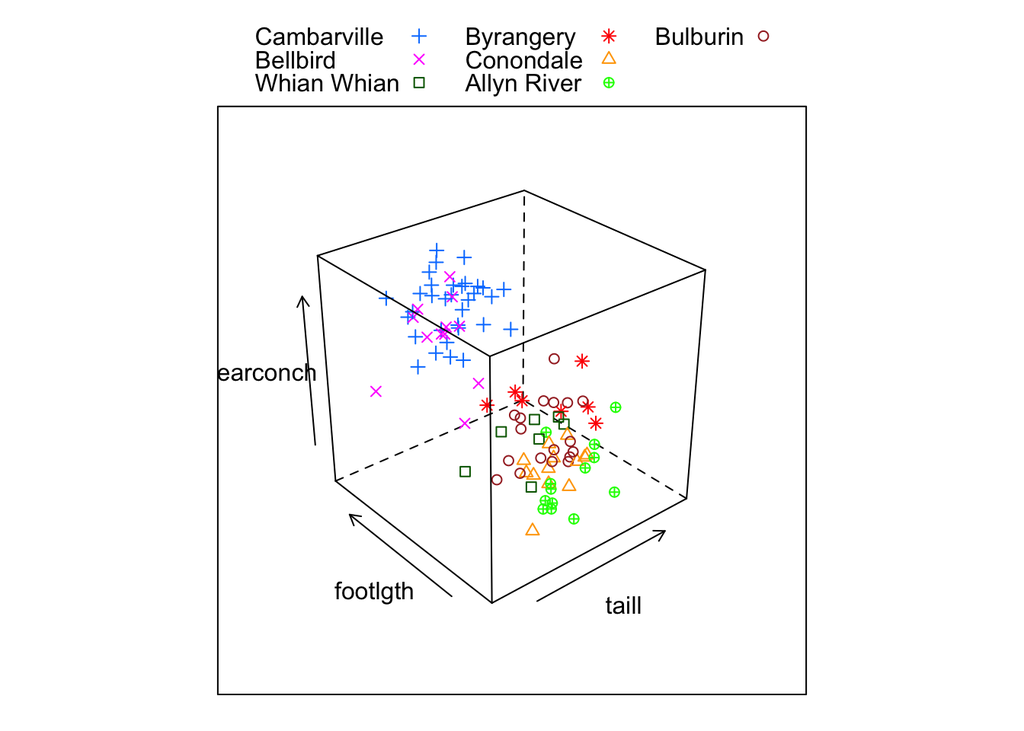

## PCA in R

```r
data.pca <- na.omit(possum[,6:14])
pca <- princomp(data.pca)
summary(pca)
```

```
## Importance of components:
##                           Comp.1    Comp.2     Comp.3     Comp.4
## Standard deviation     6.7999050 5.0331056 2.69928838 2.16009223
## Proportion of Variance 0.4981202 0.2728981 0.07849229 0.05026585
## Cumulative Proportion  0.4981202 0.7710183 0.84951059 0.89977644
##                            Comp.5     Comp.6     Comp.7     Comp.8
## Standard deviation     1.73722178 1.59889905 1.28596768 1.11105856
## Proportion of Variance 0.03251165 0.02754042 0.01781511 0.01329849
## Cumulative Proportion  0.93228809 0.95982851 0.97764362 0.99094212
##                             Comp.9
## Standard deviation     0.916957422
## Proportion of Variance 0.009057885
## Cumulative Proportion  1.000000000
```

## Factor Loadings

```r
pca$loadings
```

```
##
## Loadings:
##          Comp.1 Comp.2 Comp.3 Comp.4 Comp.5 Comp.6 Comp.7 Comp.8 Comp.9
## hdlngth   0.413  0.282  0.339 -0.185  0.695  0.277        -0.184
## skullw    0.296  0.269  0.540 -0.338 -0.519 -0.276  0.259  0.112
## totlngth  0.518  0.315 -0.648 -0.156        -0.226 -0.145  0.336
## taill            0.251 -0.350        -0.194         0.437 -0.753  0.106
## footlgth  0.514 -0.468               -0.336  0.633
## earconch  0.309 -0.650                0.249 -0.584  0.208 -0.172
## eye                                                 0.195  0.242  0.942
## chest     0.219         0.175  0.174 -0.177 -0.189 -0.763 -0.404  0.267
## belly     0.246  0.178  0.134  0.891        -0.102  0.239  0.144
##
##                Comp.1 Comp.2 Comp.3 Comp.4 Comp.5 Comp.6 Comp.7 Comp.8
## SS loadings     1.000  1.000  1.000  1.000  1.000  1.000  1.000  1.000
## Proportion Var  0.111  0.111  0.111  0.111  0.111  0.111  0.111  0.111
## Cumulative Var  0.111  0.222  0.333  0.444  0.556  0.667  0.778  0.889
##                Comp.9
## SS loadings     1.000
## Proportion Var  0.111
## Cumulative Var  1.000
```

## Eigenvalues

```r
pca$sd^2
```

```
##     Comp.1     Comp.2     Comp.3     Comp.4     Comp.5     Comp.6
## 46.2387075 25.3321515  7.2861577  4.6659984  3.0179395  2.5564782
##     Comp.7     Comp.8     Comp.9
##  1.6537129  1.2344511  0.8408109
```

## FactoMineR

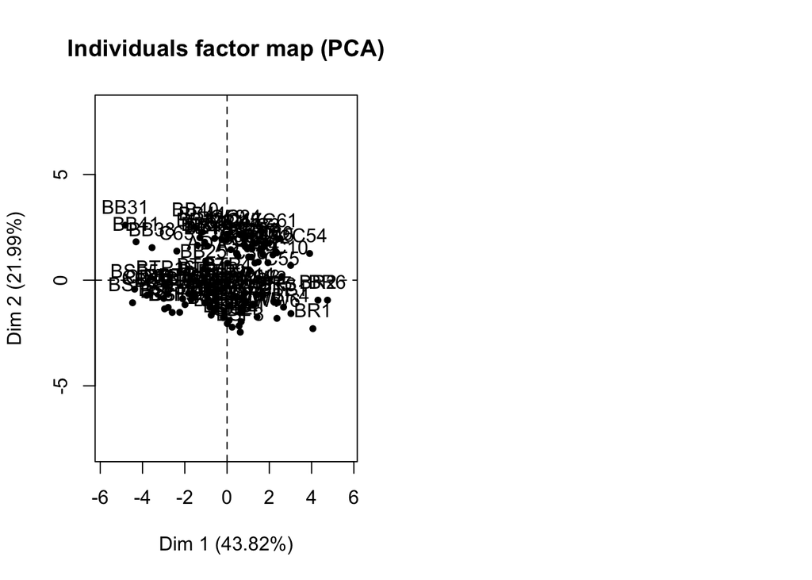

```r
require(FactoMineR)
par(mfrow = c(1,2))
pca2 <- PCA(data.pca, graph=F)
plot.PCA(pca2)
```

Calls components dimensions

## Plotting variable contibutions

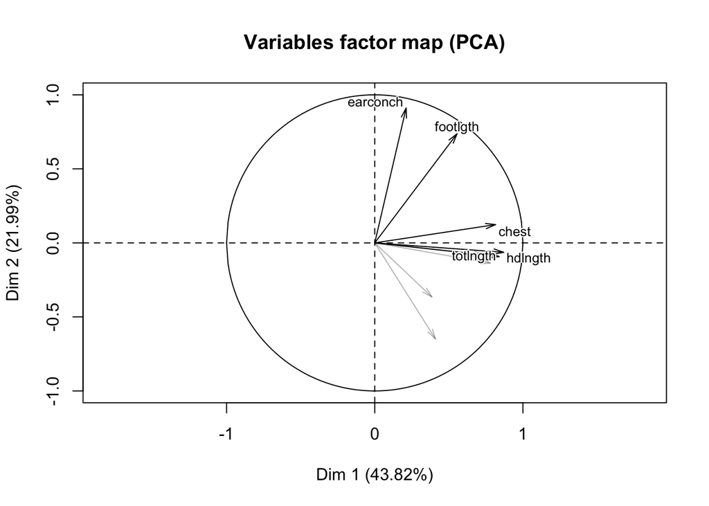

```r
plot(pca2, choix="var", shadow=TRUE, cex=.8, select = "contrib 5")
```

Only the 5 highest contributing variables are plotted

## Eigenvalues

```r
pca2$eig
```

```
##        eigenvalue percentage of variance cumulative percentage of variance
## comp 1  3.9436911              43.818790                          43.81879
## comp 2  1.9792399              21.991554                          65.81034
## comp 3  0.8911185               9.901316                          75.71166
## comp 4  0.7381412               8.201569                          83.91323
## comp 5  0.5637486               6.263874                          90.17710
## comp 6  0.3094234               3.438038                          93.61514
## comp 7  0.2667550               2.963944                          96.57909
## comp 8  0.1638545               1.820605                          98.39969
## comp 9  0.1440278               1.600309                         100.00000
```

These eigenvalues are completely different! (the first EV was 46.24)

This is because `FactoMineR`’s function `PCA()` scales the variables by default.

## Factor loadings

Loadings are not given by `FactoMineR`. But you can calculate them by dividing the principal coordinates (factor scores - `$var$coord`) of a dimension by the square root of that dimensions’ eigenvalue.

```r
sweep(pca2$var$coord,2,sqrt(pca2$eig[1:ncol(pca2$var$coord),1]),FUN="/")
```

```
##              Dim.1       Dim.2        Dim.3       Dim.4        Dim.5
## hdlngth  0.4380078 -0.04519844  0.138623007 -0.07495574 -0.238115223
## skullw   0.3927120 -0.09678900  0.223585881 -0.32364347 -0.501176778
## totlngth 0.4227082 -0.06564460 -0.312750646  0.33593765 -0.120510988
## taill    0.2061992 -0.46100652 -0.514351991  0.38374763 -0.026090130
## footlgth 0.2796247  0.52384020 -0.062416712  0.27857386 -0.002538413
## earconch 0.1067739  0.64749223 -0.004813129  0.26143915  0.017773149
## eye      0.1940729 -0.25932151  0.748023649  0.49876897  0.192020543
## chest    0.4106589  0.08780572 -0.037517222 -0.41050426  0.058210391
## belly    0.3699061 -0.05604043 -0.059633425 -0.25745316  0.797707163
```

## Scaling

```r
head(data.pca)
```

```
##     hdlngth skullw totlngth taill footlgth earconch  eye chest belly
## C3     94.1   60.4     89.0  36.0     74.5     54.5 15.2  28.0    36
## C5     92.5   57.6     91.5  36.5     72.5     51.2 16.0  28.5    33
## C10    94.0   60.0     95.5  39.0     75.4     51.9 15.5  30.0    34
## C15    93.2   57.1     92.0  38.0     76.1     52.2 15.2  28.0    34
## C23    91.5   56.3     85.5  36.0     71.0     53.2 15.1  28.5    33
## C24    93.1   54.8     90.5  35.5     73.2     53.6 14.2  30.0    32
```

## Comparing again

```r
pca3 <- princomp(scale(data.pca), cor=F)
pca4 <- princomp(scale(data.pca), cor=T)
cbind(pca2$eig, pca3$sd^2, pca4$sd^2)
```

```
##        eigenvalue percentage of variance cumulative percentage of variance
## comp 1  3.9436911              43.818790                          43.81879
## comp 2  1.9792399              21.991554                          65.81034
## comp 3  0.8911185               9.901316                          75.71166
## comp 4  0.7381412               8.201569                          83.91323
## comp 5  0.5637486               6.263874                          90.17710
## comp 6  0.3094234               3.438038                          93.61514
## comp 7  0.2667550               2.963944                          96.57909
## comp 8  0.1638545               1.820605                          98.39969
## comp 9  0.1440278               1.600309                         100.00000
##        pca3$sd^2 pca4$sd^2
## comp 1 3.9054029 3.9436911
## comp 2 1.9600239 1.9792399
## comp 3 0.8824668 0.8911185
## comp 4 0.7309748 0.7381412
## comp 5 0.5582753 0.5637486
## comp 6 0.3064193 0.3094234
## comp 7 0.2641651 0.2667550
## comp 8 0.1622637 0.1638545
## comp 9 0.1426295 0.1440278
```

## `PCA()` output

```r
summary(pca2)
```

```
##
## Call:
## PCA(X = data.pca, graph = F)
##
##
## Eigenvalues
##                        Dim.1   Dim.2   Dim.3   Dim.4   Dim.5   Dim.6
## Variance               3.944   1.979   0.891   0.738   0.564   0.309
## % of var.             43.819  21.992   9.901   8.202   6.264   3.438
## Cumulative % of var.  43.819  65.810  75.712  83.913  90.177  93.615
##                        Dim.7   Dim.8   Dim.9
## Variance               0.267   0.164   0.144
## % of var.              2.964   1.821   1.600
## Cumulative % of var.  96.579  98.400 100.000
##
## Individuals (the 10 first)
##              Dist    Dim.1    ctr   cos2    Dim.2    ctr   cos2    Dim.3
## C3       |  2.833 |  1.940  0.927  0.469 |  1.749  1.501  0.381 |  0.370
## C5       |  1.992 |  1.319  0.428  0.438 |  0.816  0.327  0.168 |  0.453
## C10      |  3.455 |  3.011  2.231  0.759 |  0.700  0.241  0.041 | -0.713
## C15      |  2.474 |  1.692  0.705  0.468 |  1.210  0.718  0.239 | -0.623
## C23      |  1.727 |  0.178  0.008  0.011 |  1.443  1.021  0.698 |  0.265
## C24      |  2.735 |  0.778  0.149  0.081 |  2.146  2.258  0.615 | -0.694
## C26      |  2.438 |  1.617  0.644  0.440 |  1.398  0.959  0.329 | -0.451
## C27      |  2.375 |  1.647  0.668  0.481 |  1.507  1.113  0.402 | -0.661
## C28      |  1.933 |  1.164  0.334  0.363 |  1.090  0.583  0.318 | -0.086
## C31      |  1.732 |  0.516  0.065  0.089 |  1.143  0.641  0.435 | -0.746
##             ctr   cos2
## C3        0.149  0.017 |
## C5        0.223  0.052 |
## C10       0.554  0.043 |
## C15       0.423  0.063 |
## C23       0.076  0.024 |
## C24       0.525  0.064 |
## C26       0.221  0.034 |
## C27       0.476  0.077 |
## C28       0.008  0.002 |
## C31       0.606  0.185 |
##
## Variables
##             Dim.1    ctr   cos2    Dim.2    ctr   cos2    Dim.3    ctr
## hdlngth  |  0.870 19.185  0.757 | -0.064  0.204  0.004 |  0.131  1.922
## skullw   |  0.780 15.422  0.608 | -0.136  0.937  0.019 |  0.211  4.999
## totlngth |  0.839 17.868  0.705 | -0.092  0.431  0.009 | -0.295  9.781
## taill    |  0.409  4.252  0.168 | -0.649 21.253  0.421 | -0.486 26.456
## footlgth |  0.555  7.819  0.308 |  0.737 27.441  0.543 | -0.059  0.390
## earconch |  0.212  1.140  0.045 |  0.911 41.925  0.830 | -0.005  0.002
## eye      |  0.385  3.766  0.149 | -0.365  6.725  0.133 |  0.706 55.954
## chest    |  0.816 16.864  0.665 |  0.124  0.771  0.015 | -0.035  0.141
## belly    |  0.735 13.683  0.540 | -0.079  0.314  0.006 | -0.056  0.356
##            cos2
## hdlngth   0.017 |
## skullw    0.045 |
## totlngth  0.087 |
## taill     0.236 |
## footlgth  0.003 |
## earconch  0.000 |
## eye       0.499 |
## chest     0.001 |
## belly     0.003 |
```

## `PCA()`: output

The distance of the individual to the center of gravity of the cloud

```r
head(pca2$ind$dist)
```

```
##       C3       C5      C10      C15      C23      C24
## 2.832549 1.991918 3.455249 2.474039 1.726555 2.734898
```

Coordinates on the dimensions:

```r
head(pca2$ind$coord)
```

```
##         Dim.1     Dim.2      Dim.3       Dim.4        Dim.5
## C3  1.9402163 1.7491541  0.3697951 -0.09682066  0.362202294
## C5  1.3190309 0.8160159  0.4525764  0.74172674  0.122100338
## C10 3.0107066 0.7002710 -0.7130430  0.86079860 -0.268486067
## C15 1.6917423 1.2099217 -0.6229124  1.03172615  0.252596255
## C23 0.1782035 1.4427805  0.2647067 -0.06436846  0.418219556
## C24 0.7775502 2.1455386 -0.6943664 -0.11904883  0.007056481
```

## `PCA()`: output

Contribution of individuals to the construction of the dimensions

```r
head(pca2$ind$contrib)
```

```
##           Dim.1     Dim.2      Dim.3       Dim.4        Dim.5
## C3  0.926744886 1.5007919 0.14898745 0.012329895 2.259330e-01
## C5  0.428321417 0.3266341 0.22315730 0.723621095 2.567503e-02
## C10 2.231499259 0.2405451 0.55393490 0.974600085 1.241426e-01
## C15 0.704576712 0.7180901 0.42274777 1.400077965 1.098831e-01
## C23 0.007817944 1.0210920 0.07634089 0.005449662 3.012215e-01
## C24 0.148839004 2.2580681 0.52529673 0.018641190 8.575385e-05
```

Quality of representation of the individual on the dimension (square of the cosine). Close to `1` means well-projected on the axis.

```r
head(pca2$ind$cos2)
```

```
##          Dim.1      Dim.2      Dim.3       Dim.4        Dim.5
## C3  0.46918659 0.38133037 0.01704385 0.001168372 1.635113e-02
## C5  0.43849740 0.16782411 0.05162272 0.138658020 3.757430e-03
## C10 0.75923844 0.04107462 0.04258658 0.062064667 6.037885e-03
## C15 0.46757938 0.23916714 0.06339295 0.173906505 1.042415e-02
## C23 0.01065300 0.69829621 0.02350548 0.001389906 5.867429e-02
## C24 0.08083036 0.61544653 0.06446070 0.001894820 6.657237e-06
```

## Course material

It will remain online for at least a month.

If you have a question: e-mail me: G.Vink [at] uu [dot] nl

[figure not shown]